# Non-psychometric MLE

```r
anova(nonpsych2, nonpsych.a, nonpsych.b, nonpsych.c, nonpsych.d, nonpsych.e, nonpsych.f, nonpsych.g, nonpsych.h, nonpsych.i, nonpsych.j, nonpsych.k, nonpsych.l, nonpsych.m, nonpsych.n, nonpsych.o)[order(row.names(anova(nonpsych2, nonpsych.a, nonpsych.b, nonpsych.c, nonpsych.d, nonpsych.e, nonpsych.f, nonpsych.g, nonpsych.h, nonpsych.i, nonpsych.j, nonpsych.k, nonpsych.l, nonpsych.m, nonpsych.n, nonpsych.o))),]
```

```
## Data: data
## Models:
## nonpsych.o: cbind(corr, incorr) ~ (1 + Colour.difference | batch) + (1 |
## nonpsych.o:     batch)
## nonpsych.n: cbind(corr, incorr) ~ Colour.difference + (1 + Colour.difference |
## nonpsych.n:     chick) + (1 + Colour.difference | batch)
## nonpsych.m: cbind(corr, incorr) ~ Colour.difference + target + (1 + Colour.difference |
## nonpsych.m:     chick) + (1 + Colour.difference | batch)
## nonpsych.l: cbind(corr, incorr) ~ Colour.difference + target + sex + (1 +
## nonpsych.l:     Colour.difference | chick) + (1 + Colour.difference | batch)
## nonpsych.k: cbind(corr, incorr) ~ Colour.difference + background + target +
## nonpsych.k:     sex + (1 + Colour.difference | chick) + (1 + Colour.difference +
## nonpsych.k:     background | batch)
## nonpsych.j: cbind(corr, incorr) ~ Colour.difference + background + target +
## nonpsych.j:     sex + (1 + Colour.difference | chick) + (1 + Colour.difference +
## nonpsych.j:     background | batch) + target:sex
## nonpsych.i: cbind(corr, incorr) ~ Colour.difference + background + target +
## nonpsych.i:     sex + (1 + Colour.difference | chick) + (1 + Colour.difference +
## nonpsych.i:     background | batch) + Colour.difference:target + target:sex
## nonpsych.h: cbind(corr, incorr) ~ Colour.difference + background + target +
## nonpsych.h:     sex + (1 + Colour.difference | chick) + (1 + Colour.difference +
## nonpsych.h:     background | batch) + Colour.difference:target + background:target +
## nonpsych.h:     target:sex
## nonpsych.g: cbind(corr, incorr) ~ Colour.difference + background + target +
## nonpsych.g:     sex + (1 + Colour.difference | chick) + (1 + Colour.difference *
## nonpsych.g:     background | batch) + Colour.difference:background + Colour.difference:target +
## nonpsych.g:     background:target + target:sex
## nonpsych.f: cbind(corr, incorr) ~ Colour.difference + background + target +
## nonpsych.f:     sex + (1 + Colour.difference | chick) + (1 + Colour.difference *
## nonpsych.f:     background | batch) + Colour.difference:background + Colour.difference:target +
## nonpsych.f:     background:target + background:sex + target:sex
## nonpsych.e: cbind(corr, incorr) ~ Colour.difference + background + target +
## nonpsych.e:     sex + (1 + Colour.difference | chick) + (1 + Colour.difference *
## nonpsych.e:     background | batch) + Colour.difference:background + Colour.difference:target +
## nonpsych.e:     background:target + Colour.difference:sex + background:sex +
## nonpsych.e:     target:sex
## nonpsych.d: cbind(corr, incorr) ~ Colour.difference + background + target +
## nonpsych.d:     sex + (1 + Colour.difference | chick) + (1 + Colour.difference *
## nonpsych.d:     background | batch) + Colour.difference:background + Colour.difference:target +
## nonpsych.d:     background:target + Colour.difference:sex + background:sex +
```

[output cut: 25 more lines]

```
## nonpsych.d   25  994.31 1071.8 -472.15   944.31   0.6126  1  0.4338281
## nonpsych.e   24  992.92 1067.3 -472.46   944.92   0.1463  1  0.7020980
## nonpsych.f   23  991.07 1062.4 -472.53   945.07   0.4782  1  0.4892392
## nonpsych.g   22  989.55 1057.7 -472.77   945.55   0.6770  5  0.9842072
## nonpsych.h   17  980.22 1032.9 -473.11   946.22   3.1688  1  0.0750589 .
## nonpsych.i   16  981.39 1031.0 -474.70   949.39   3.4825  1  0.0620223 .
## nonpsych.j   15  982.87 1029.4 -476.44   952.87   2.4527  1  0.1173220
## nonpsych.k   14  983.33 1026.7 -477.66   955.33   2.6619  4  0.6158920
## nonpsych.l   10  977.99 1009.0 -478.99   957.99   0.3568  1  0.5503130
## nonpsych.m    9  976.35 1004.2 -479.17   958.35  14.7681  1  0.0001216 ***
## nonpsych.n    8  989.11 1013.9 -486.56   973.11 144.1549  3  < 2.2e-16 ***
## nonpsych.o    5 1127.27 1142.8 -558.63  1117.27
## nonpsych2    29 1001.86 1091.8 -471.93   943.86   0.0010  1  0.9746008
## ---
## Signif. codes:  0 '***' 0.001 '**' 0.01 '*' 0.05 '.' 0.1 ' ' 1
```

We use the anova function to compare AIC and model deviance.

```r
anova(nonpsych2, nonpsych.a, nonpsych.b, nonpsych.c, nonpsych.d, nonpsych.e, nonpsych.f, nonpsych.g, nonpsych.h, nonpsych.i, nonpsych.j, nonpsych.k, nonpsych.l, nonpsych.m, nonpsych.n, nonpsych.o)[rev(order(AIC(nonpsych2, nonpsych.a, nonpsych.b, nonpsych.c, nonpsych.d, nonpsych.e, nonpsych.f, nonpsych.g, nonpsych.h, nonpsych.i, nonpsych.j, nonpsych.k, nonpsych.l, nonpsych.m, nonpsych.n, nonpsych.o)$AIC)),]
```

```
## Data: data
## Models:
## nonpsych.o: cbind(corr, incorr) ~ (1 + Colour.difference | batch) + (1 |
## nonpsych.o:     batch)
## nonpsych.n: cbind(corr, incorr) ~ Colour.difference + (1 + Colour.difference |
## nonpsych.n:     chick) + (1 + Colour.difference | batch)
## nonpsych.m: cbind(corr, incorr) ~ Colour.difference + target + (1 + Colour.difference |
## nonpsych.m:     chick) + (1 + Colour.difference | batch)
## nonpsych.l: cbind(corr, incorr) ~ Colour.difference + target + sex + (1 +
## nonpsych.l:     Colour.difference | chick) + (1 + Colour.difference | batch)
## nonpsych.k: cbind(corr, incorr) ~ Colour.difference + background + target +
## nonpsych.k:     sex + (1 + Colour.difference | chick) + (1 + Colour.difference +
## nonpsych.k:     background | batch)
## nonpsych.j: cbind(corr, incorr) ~ Colour.difference + background + target +
## nonpsych.j:     sex + (1 + Colour.difference | chick) + (1 + Colour.difference +
## nonpsych.j:     background | batch) + target:sex
## nonpsych.i: cbind(corr, incorr) ~ Colour.difference + background + target +
## nonpsych.i:     sex + (1 + Colour.difference | chick) + (1 + Colour.difference +
## nonpsych.i:     background | batch) + Colour.difference:target + target:sex
## nonpsych.h: cbind(corr, incorr) ~ Colour.difference + background + target +
## nonpsych.h:     sex + (1 + Colour.difference | chick) + (1 + Colour.difference +
## nonpsych.h:     background | batch) + Colour.difference:target + background:target +
## nonpsych.h:     target:sex
## nonpsych.g: cbind(corr, incorr) ~ Colour.difference + background + target +
## nonpsych.g:     sex + (1 + Colour.difference | chick) + (1 + Colour.difference *
## nonpsych.g:     background | batch) + Colour.difference:background + Colour.difference:target +
## nonpsych.g:     background:target + target:sex
## nonpsych.f: cbind(corr, incorr) ~ Colour.difference + background + target +
## nonpsych.f:     sex + (1 + Colour.difference | chick) + (1 + Colour.difference *
## nonpsych.f:     background | batch) + Colour.difference:background + Colour.difference:target +
## nonpsych.f:     background:target + background:sex + target:sex
## nonpsych.e: cbind(corr, incorr) ~ Colour.difference + background + target +
## nonpsych.e:     sex + (1 + Colour.difference | chick) + (1 + Colour.difference *
## nonpsych.e:     background | batch) + Colour.difference:background + Colour.difference:target +
## nonpsych.e:     background:target + Colour.difference:sex + background:sex +
## nonpsych.e:     target:sex
## nonpsych.d: cbind(corr, incorr) ~ Colour.difference + background + target +
## nonpsych.d:     sex + (1 + Colour.difference | chick) + (1 + Colour.difference *
## nonpsych.d:     background | batch) + Colour.difference:background + Colour.difference:target +
## nonpsych.d:     background:target + Colour.difference:sex + background:sex +
```

[output cut: 25 more lines]

```
## nonpsych.m    9  976.35 1004.2 -479.17   958.35  14.7681  1  0.0001216 ***
## nonpsych.l   10  977.99 1009.0 -478.99   957.99   0.3568  1  0.5503130
## nonpsych.k   14  983.33 1026.7 -477.66   955.33   2.6619  4  0.6158920
## nonpsych.j   15  982.87 1029.4 -476.44   952.87   2.4527  1  0.1173220
## nonpsych.i   16  981.39 1031.0 -474.70   949.39   3.4825  1  0.0620223 .
## nonpsych.h   17  980.22 1032.9 -473.11   946.22   3.1688  1  0.0750589 .
## nonpsych.a   28  999.86 1086.7 -471.93   943.86   0.0285  1  0.8658964
## nonpsych.d   25  994.31 1071.8 -472.15   944.31   0.6126  1  0.4338281
## nonpsych.e   24  992.92 1067.3 -472.46   944.92   0.1463  1  0.7020980
## nonpsych.f   23  991.07 1062.4 -472.53   945.07   0.4782  1  0.4892392
## nonpsych.g   22  989.55 1057.7 -472.77   945.55   0.6770  5  0.9842072
## nonpsych.c   26  996.01 1076.6 -472.01   944.01   0.2978  1  0.5852428
## nonpsych.b   27  997.89 1081.6 -471.95   943.89   0.1188  1  0.7303385
## ---
## Signif. codes:  0 '***' 0.001 '**' 0.01 '*' 0.05 '.' 0.1 ' ' 1
```

```r
anova(nonpsych2, nonpsych.a)
```

```
## Data: data
## Models:
## nonpsych.a: cbind(corr, incorr) ~ Colour.difference + background + target +
## nonpsych.a:     sex + (1 + Colour.difference | chick) + (1 + Colour.difference *
## nonpsych.a:     background | batch) + Colour.difference:background + Colour.difference:target +
## nonpsych.a:     background:target + Colour.difference:sex + background:sex +
## nonpsych.a:     target:sex + Colour.difference:background:target + Colour.difference:background:sex +
## nonpsych.a:     Colour.difference:target:sex + background:target:sex
## nonpsych2: cbind(corr, incorr) ~ Colour.difference * background * target *
## nonpsych2:     sex + (1 + Colour.difference | chick) + (1 + Colour.difference *
## nonpsych2:     background | batch)
##            npar     AIC    BIC  logLik deviance Chisq Df Pr(>Chisq)
## nonpsych.a   28  999.86 1086.7 -471.93   943.86
## nonpsych2    29 1001.86 1091.8 -471.93   943.86 0.001  1     0.9746
```

# 20200420 reviewer’s comments ———————————

Previous model selection procedure: 1. If m1 and m2 are not significantly different, keep m1. 2. If model 1 and m2 are significantly different and m1 has lower AIC, keep m1. 3. If m1 and m2 are significantly different and m2 has lower AIC, choose m2. NEW model selection procedure: 1. If m1 and m2 are not significantly different, choose m2. 2. If m1 and m2 are significantly different and m1 has lower AIC, keep m1. 3. If m1 and m2 are significantly different and m2 has lower AIC, choose m2.

```r
anova(nonpsych2, nonpsych.a)
```

```
## Data: data
## Models:
## nonpsych.a: cbind(corr, incorr) ~ Colour.difference + background + target +
## nonpsych.a:     sex + (1 + Colour.difference | chick) + (1 + Colour.difference *
## nonpsych.a:     background | batch) + Colour.difference:background + Colour.difference:target +
## nonpsych.a:     background:target + Colour.difference:sex + background:sex +
## nonpsych.a:     target:sex + Colour.difference:background:target + Colour.difference:background:sex +
## nonpsych.a:     Colour.difference:target:sex + background:target:sex
## nonpsych2: cbind(corr, incorr) ~ Colour.difference * background * target *
## nonpsych2:     sex + (1 + Colour.difference | chick) + (1 + Colour.difference *
## nonpsych2:     background | batch)
##            npar     AIC    BIC  logLik deviance Chisq Df Pr(>Chisq)
## nonpsych.a   28  999.86 1086.7 -471.93   943.86
## nonpsych2    29 1001.86 1091.8 -471.93   943.86 0.001  1     0.9746
```

Rule 1, drop Colour.difference:background:target:sex

```r
anova(nonpsych.a, nonpsych.b)
```

```
## Data: data
## Models:
## nonpsych.b: cbind(corr, incorr) ~ Colour.difference + background + target +
## nonpsych.b:     sex + (1 + Colour.difference | chick) + (1 + Colour.difference *
## nonpsych.b:     background | batch) + Colour.difference:background + Colour.difference:target +
## nonpsych.b:     background:target + Colour.difference:sex + background:sex +
## nonpsych.b:     target:sex + Colour.difference:background:target + Colour.difference:background:sex +
## nonpsych.b:     background:target:sex
## nonpsych.a: cbind(corr, incorr) ~ Colour.difference + background + target +
## nonpsych.a:     sex + (1 + Colour.difference | chick) + (1 + Colour.difference *
## nonpsych.a:     background | batch) + Colour.difference:background + Colour.difference:target +
## nonpsych.a:     background:target + Colour.difference:sex + background:sex +
## nonpsych.a:     target:sex + Colour.difference:background:target + Colour.difference:background:sex +
## nonpsych.a:     Colour.difference:target:sex + background:target:sex
##            npar    AIC    BIC  logLik deviance  Chisq Df Pr(>Chisq)
## nonpsych.b   27 997.89 1081.6 -471.95   943.89
## nonpsych.a   28 999.86 1086.7 -471.93   943.86 0.0285  1     0.8659
```

Rule 1, drop Colour.difference:target:sex

```r
anova(nonpsych.b,nonpsych.c)
```

```
## Data: data
## Models:
## nonpsych.c: cbind(corr, incorr) ~ Colour.difference + background + target +
## nonpsych.c:     sex + (1 + Colour.difference | chick) + (1 + Colour.difference *
## nonpsych.c:     background | batch) + Colour.difference:background + Colour.difference:target +
## nonpsych.c:     background:target + Colour.difference:sex + background:sex +
## nonpsych.c:     target:sex + Colour.difference:background:target + background:target:sex
## nonpsych.b: cbind(corr, incorr) ~ Colour.difference + background + target +
## nonpsych.b:     sex + (1 + Colour.difference | chick) + (1 + Colour.difference *
## nonpsych.b:     background | batch) + Colour.difference:background + Colour.difference:target +
## nonpsych.b:     background:target + Colour.difference:sex + background:sex +
## nonpsych.b:     target:sex + Colour.difference:background:target + Colour.difference:background:sex +
## nonpsych.b:     background:target:sex
##            npar    AIC    BIC  logLik deviance  Chisq Df Pr(>Chisq)
## nonpsych.c   26 996.01 1076.6 -472.01   944.01
## nonpsych.b   27 997.89 1081.6 -471.95   943.89 0.1188  1     0.7303
```

Rule 1, drop Colour.difference:background:sex

```r
anova(nonpsych.c,nonpsych.d)
```

```
## Data: data
## Models:
## nonpsych.d: cbind(corr, incorr) ~ Colour.difference + background + target +
## nonpsych.d:     sex + (1 + Colour.difference | chick) + (1 + Colour.difference *
## nonpsych.d:     background | batch) + Colour.difference:background + Colour.difference:target +
## nonpsych.d:     background:target + Colour.difference:sex + background:sex +
## nonpsych.d:     target:sex + background:target:sex
## nonpsych.c: cbind(corr, incorr) ~ Colour.difference + background + target +
## nonpsych.c:     sex + (1 + Colour.difference | chick) + (1 + Colour.difference *
## nonpsych.c:     background | batch) + Colour.difference:background + Colour.difference:target +
## nonpsych.c:     background:target + Colour.difference:sex + background:sex +
## nonpsych.c:     target:sex + Colour.difference:background:target + background:target:sex
##            npar    AIC    BIC  logLik deviance  Chisq Df Pr(>Chisq)
## nonpsych.d   25 994.31 1071.8 -472.15   944.31
## nonpsych.c   26 996.01 1076.6 -472.01   944.01 0.2978  1     0.5852
```

Rule 1, drop Colour.difference:background:target

```r
anova(nonpsych.d,nonpsych.e)
```

```
## Data: data
## Models:
## nonpsych.e: cbind(corr, incorr) ~ Colour.difference + background + target +
## nonpsych.e:     sex + (1 + Colour.difference | chick) + (1 + Colour.difference *
## nonpsych.e:     background | batch) + Colour.difference:background + Colour.difference:target +
## nonpsych.e:     background:target + Colour.difference:sex + background:sex +
## nonpsych.e:     target:sex
## nonpsych.d: cbind(corr, incorr) ~ Colour.difference + background + target +
## nonpsych.d:     sex + (1 + Colour.difference | chick) + (1 + Colour.difference *
## nonpsych.d:     background | batch) + Colour.difference:background + Colour.difference:target +
## nonpsych.d:     background:target + Colour.difference:sex + background:sex +
## nonpsych.d:     target:sex + background:target:sex
##            npar    AIC    BIC  logLik deviance  Chisq Df Pr(>Chisq)
## nonpsych.e   24 992.92 1067.3 -472.46   944.92
## nonpsych.d   25 994.31 1071.8 -472.15   944.31 0.6126  1     0.4338
```

Rule 1, drop background:target:sex

```r
anova(nonpsych.e,nonpsych.f)
```

```
## Data: data
## Models:
## nonpsych.f: cbind(corr, incorr) ~ Colour.difference + background + target +
## nonpsych.f:     sex + (1 + Colour.difference | chick) + (1 + Colour.difference *
## nonpsych.f:     background | batch) + Colour.difference:background + Colour.difference:target +
## nonpsych.f:     background:target + background:sex + target:sex
## nonpsych.e: cbind(corr, incorr) ~ Colour.difference + background + target +
## nonpsych.e:     sex + (1 + Colour.difference | chick) + (1 + Colour.difference *
## nonpsych.e:     background | batch) + Colour.difference:background + Colour.difference:target +
## nonpsych.e:     background:target + Colour.difference:sex + background:sex +
## nonpsych.e:     target:sex
##            npar    AIC    BIC  logLik deviance  Chisq Df Pr(>Chisq)
## nonpsych.f   23 991.07 1062.4 -472.53   945.07
## nonpsych.e   24 992.92 1067.3 -472.46   944.92 0.1463  1     0.7021
```

Rule 1, drop Colour.difference:sex

```r
anova(nonpsych.f,nonpsych.g)
```

```
## Data: data
## Models:
## nonpsych.g: cbind(corr, incorr) ~ Colour.difference + background + target +
## nonpsych.g:     sex + (1 + Colour.difference | chick) + (1 + Colour.difference *
## nonpsych.g:     background | batch) + Colour.difference:background + Colour.difference:target +
## nonpsych.g:     background:target + target:sex
## nonpsych.f: cbind(corr, incorr) ~ Colour.difference + background + target +
## nonpsych.f:     sex + (1 + Colour.difference | chick) + (1 + Colour.difference *
## nonpsych.f:     background | batch) + Colour.difference:background + Colour.difference:target +
## nonpsych.f:     background:target + background:sex + target:sex
##            npar    AIC    BIC  logLik deviance  Chisq Df Pr(>Chisq)
## nonpsych.g   22 989.55 1057.7 -472.77   945.55
## nonpsych.f   23 991.07 1062.4 -472.53   945.07 0.4782  1     0.4892
```

Rule 1, drop background:sex

```r
anova(nonpsych.g,nonpsych.h)
```

```
## Data: data
## Models:
## nonpsych.h: cbind(corr, incorr) ~ Colour.difference + background + target +
## nonpsych.h:     sex + (1 + Colour.difference | chick) + (1 + Colour.difference +
## nonpsych.h:     background | batch) + Colour.difference:target + background:target +
## nonpsych.h:     target:sex
## nonpsych.g: cbind(corr, incorr) ~ Colour.difference + background + target +
## nonpsych.g:     sex + (1 + Colour.difference | chick) + (1 + Colour.difference *
## nonpsych.g:     background | batch) + Colour.difference:background + Colour.difference:target +
## nonpsych.g:     background:target + target:sex
##            npar    AIC    BIC  logLik deviance Chisq Df Pr(>Chisq)
## nonpsych.h   17 980.22 1032.9 -473.11   946.22
## nonpsych.g   22 989.55 1057.7 -472.77   945.55 0.677  5     0.9842
```

Rule 1, drop Colour.difference:background

```r
anova(nonpsych.h,nonpsych.i)
```

```
## Data: data
## Models:
## nonpsych.i: cbind(corr, incorr) ~ Colour.difference + background + target +
## nonpsych.i:     sex + (1 + Colour.difference | chick) + (1 + Colour.difference +
## nonpsych.i:     background | batch) + Colour.difference:target + target:sex
## nonpsych.h: cbind(corr, incorr) ~ Colour.difference + background + target +
## nonpsych.h:     sex + (1 + Colour.difference | chick) + (1 + Colour.difference +
## nonpsych.h:     background | batch) + Colour.difference:target + background:target +
## nonpsych.h:     target:sex
##            npar    AIC    BIC  logLik deviance  Chisq Df Pr(>Chisq)
## nonpsych.i   16 981.39 1031.0 -474.70   949.39
## nonpsych.h   17 980.22 1032.9 -473.11   946.22 3.1688  1    0.07506 .
## ---
## Signif. codes:  0 '***' 0.001 '**' 0.01 '*' 0.05 '.' 0.1 ' ' 1
```

Rule 1, drop background:target N.B. AIC now increasing!

```r
anova(nonpsych.i,nonpsych.j)
```

```
## Data: data
## Models:
## nonpsych.j: cbind(corr, incorr) ~ Colour.difference + background + target +
## nonpsych.j:     sex + (1 + Colour.difference | chick) + (1 + Colour.difference +
## nonpsych.j:     background | batch) + target:sex
## nonpsych.i: cbind(corr, incorr) ~ Colour.difference + background + target +
## nonpsych.i:     sex + (1 + Colour.difference | chick) + (1 + Colour.difference +
## nonpsych.i:     background | batch) + Colour.difference:target + target:sex
##            npar    AIC    BIC  logLik deviance  Chisq Df Pr(>Chisq)
## nonpsych.j   15 982.87 1029.4 -476.44   952.87
## nonpsych.i   16 981.39 1031.0 -474.70   949.39 3.4825  1    0.06202 .
## ---
## Signif. codes:  0 '***' 0.001 '**' 0.01 '*' 0.05 '.' 0.1 ' ' 1
```

Rule 1, I suppose, drop Colour.difference:target N.B. AIC now increasing!

```r
anova(nonpsych.j,nonpsych.k)
```

```
## Data: data
## Models:
## nonpsych.k: cbind(corr, incorr) ~ Colour.difference + background + target +
## nonpsych.k:     sex + (1 + Colour.difference | chick) + (1 + Colour.difference +
## nonpsych.k:     background | batch)
## nonpsych.j: cbind(corr, incorr) ~ Colour.difference + background + target +
## nonpsych.j:     sex + (1 + Colour.difference | chick) + (1 + Colour.difference +
## nonpsych.j:     background | batch) + target:sex
##            npar    AIC    BIC  logLik deviance  Chisq Df Pr(>Chisq)
## nonpsych.k   14 983.33 1026.7 -477.66   955.33
## nonpsych.j   15 982.87 1029.4 -476.44   952.87 2.4527  1     0.1173
```

Rule 1, I suppose, drop target:sex N.B. AIC now increasing!

```r
anova(nonpsych.k,nonpsych.l)
```

```
## Data: data
## Models:
## nonpsych.l: cbind(corr, incorr) ~ Colour.difference + target + sex + (1 +
## nonpsych.l:     Colour.difference | chick) + (1 + Colour.difference | batch)
## nonpsych.k: cbind(corr, incorr) ~ Colour.difference + background + target +
## nonpsych.k:     sex + (1 + Colour.difference | chick) + (1 + Colour.difference +
## nonpsych.k:     background | batch)
##            npar    AIC    BIC  logLik deviance  Chisq Df Pr(>Chisq)
## nonpsych.l   10 977.99 1009.0 -478.99   957.99
## nonpsych.k   14 983.33 1026.7 -477.66   955.33 2.6619  4     0.6159
```

Rule 1, drop background

```r
anova(nonpsych.l,nonpsych.m)
```

```
## Data: data
## Models:
## nonpsych.m: cbind(corr, incorr) ~ Colour.difference + target + (1 + Colour.difference |
## nonpsych.m:     chick) + (1 + Colour.difference | batch)
## nonpsych.l: cbind(corr, incorr) ~ Colour.difference + target + sex + (1 +
## nonpsych.l:     Colour.difference | chick) + (1 + Colour.difference | batch)
##            npar    AIC    BIC  logLik deviance  Chisq Df Pr(>Chisq)
## nonpsych.m    9 976.35 1004.2 -479.17   958.35
## nonpsych.l   10 977.99 1009.0 -478.99   957.99 0.3568  1     0.5503
```

Rule 1, drop sex

```r
anova(nonpsych.m,nonpsych.n)
```

```
## Data: data
## Models:
## nonpsych.n: cbind(corr, incorr) ~ Colour.difference + (1 + Colour.difference |
## nonpsych.n:     chick) + (1 + Colour.difference | batch)
## nonpsych.m: cbind(corr, incorr) ~ Colour.difference + target + (1 + Colour.difference |
## nonpsych.m:     chick) + (1 + Colour.difference | batch)
##            npar    AIC    BIC  logLik deviance  Chisq Df Pr(>Chisq)
## nonpsych.n    8 989.11 1013.9 -486.56   973.11
## nonpsych.m    9 976.35 1004.2 -479.17   958.35 14.768  1  0.0001216 ***
## ---
## Signif. codes:  0 '***' 0.001 '**' 0.01 '*' 0.05 '.' 0.1 ' ' 1
```

Rule 2, keep target

```r
nonpsych.m1 <- update(nonpsych.m, .~. - Colour.difference -
                            (1 + Colour.difference | chick) -
                            (1 + Colour.difference | batch)
                            + (1 | chick) +
                            (1 | batch)
                                                    )
anova(nonpsych.m,nonpsych.m1)
```

```
## Data: data
## Models:
## nonpsych.m1: cbind(corr, incorr) ~ target + (1 | chick) + (1 | batch)
## nonpsych.m: cbind(corr, incorr) ~ Colour.difference + target + (1 + Colour.difference |
## nonpsych.m:     chick) + (1 + Colour.difference | batch)
##             npar     AIC    BIC  logLik deviance  Chisq Df Pr(>Chisq)
## nonpsych.m1    4 1927.51 1939.9 -959.76  1919.51
## nonpsych.m     9  976.35 1004.2 -479.17   958.35 961.17  5  < 2.2e-16 ***
## ---
## Signif. codes:  0 '***' 0.001 '**' 0.01 '*' 0.05 '.' 0.1 ' ' 1
```

Rule 2, keep Colour.difference So final model, according to reviewer 2

```r
formula(nonpsych.m)
```

```
## cbind(corr, incorr) ~ Colour.difference + target + (1 + Colour.difference |
##     chick) + (1 + Colour.difference | batch)
```

# hypothesis testing —————————

```r
ls.comps <- lsmeans(nonpsych.m, list(pairwise ~ target))
summary(ls.comps)[2]
```

```
## $`pairwise differences of target`
##  contrast    estimate   SE  df z.ratio p.value
##  diff - same   -0.579 0.13 Inf -4.454  <.0001
##
## Results are given on the log odds ratio (not the response) scale.
```

# 20200806 reviewer’s comments ———————————

L662: what models do you compare. You should compare against the final model, i.e. the model that has only significant terms in it. if you use the full model, you underestimate your probabilities as you underestimate your residual variance. Please make clear what your comparison is.

```r
formula(nonpsych.m)#final model, with only "significant terms"
```

```
## cbind(corr, incorr) ~ Colour.difference + target + (1 + Colour.difference |
##     chick) + (1 + Colour.difference | batch)
```

extract only vital info

```r
ifo <- c("deviance","Chisq","Df","Pr(>Chisq)")
```

terms to test # . sex

```r
anova(nonpsych.m, update(nonpsych.m, .~. +sex))[ifo]
```

```
##                                 deviance  Chisq Df Pr(>Chisq)
## nonpsych.m                        958.35
## update(nonpsych.m, . ~ . + sex)   957.99 0.3568  1     0.5503
```

# . background

```r
anova(nonpsych.m, update(nonpsych.m, .~. +background))[ifo]
```

```
##                                        deviance  Chisq Df Pr(>Chisq)
## nonpsych.m                               958.35
## update(nonpsych.m, . ~ . + background)   958.32 0.0292  1     0.8644
```

# . same:sex

```r
anova(nonpsych.m, update(nonpsych.m, .~. +target*sex))[ifo]
```

```
##                                          deviance  Chisq Df Pr(>Chisq)
## nonpsych.m                                 958.35
## update(nonpsych.m, . ~ . + target * sex)   955.99 2.3526  2     0.3084
```

# . Colour.difference:target

```r
anova(nonpsych.m, update(nonpsych.m, .~. +Colour.difference*target))[ifo]
```

```
##                                                        deviance  Chisq Df
## nonpsych.m                                               958.35
## update(nonpsych.m, . ~ . + Colour.difference * target)   955.23 3.1199  1
##                                                        Pr(>Chisq)
## nonpsych.m
## update(nonpsych.m, . ~ . + Colour.difference * target)    0.07734 .
## ---
## Signif. codes:  0 '***' 0.001 '**' 0.01 '*' 0.05 '.' 0.1 ' ' 1
```

# . background:target

```r
anova(nonpsych.m, update(nonpsych.m, .~. +background*target))[ifo]
```

```
##                                                 deviance  Chisq Df Pr(>Chisq)
## nonpsych.m                                        958.35
## update(nonpsych.m, . ~ . + background * target)   956.35 1.9927  2     0.3692
```

# . Colour.difference:background

```r
anova(nonpsych.m, update(nonpsych.m, .~. +Colour.difference*background))[ifo]
```

```
##                                                            deviance  Chisq Df
## nonpsych.m                                                   958.35
## update(nonpsych.m, . ~ . + Colour.difference * background)   957.68 0.6674  2
##                                                            Pr(>Chisq)
## nonpsych.m
## update(nonpsych.m, . ~ . + Colour.difference * background)     0.7163
```

# . background:sex

```r
anova(nonpsych.m, update(nonpsych.m, .~. +background*sex))[ifo]
```

```
##                                              deviance  Chisq Df Pr(>Chisq)
## nonpsych.m                                     958.35
## update(nonpsych.m, . ~ . + background * sex)   957.30 1.0469  3     0.7899
```

# . Colour.difference:sex

```r
anova(nonpsych.m, update(nonpsych.m, .~. +Colour.difference*sex))[ifo]
```

```
##                                                     deviance  Chisq Df
## nonpsych.m                                            958.35
## update(nonpsych.m, . ~ . + Colour.difference * sex)   957.86 0.4841  2
##                                                     Pr(>Chisq)
## nonpsych.m
## update(nonpsych.m, . ~ . + Colour.difference * sex)      0.785
```

# . background:target:sex

```r
anova(nonpsych.m, update(nonpsych.m, .~. +background*target*sex)
    )[2,ifo]
```

```
##                                                       deviance  Chisq Df
## update(nonpsych.m, . ~ . + background * target * sex)   952.28 6.0654  6
##                                                       Pr(>Chisq)
## update(nonpsych.m, . ~ . + background * target * sex)     0.4159
```

# . Colour.difference:background:target

```r
unlist(
  anova(nonpsych.m, update(nonpsych.m, .~. +Colour.difference*background*target)
        )[2,ifo]
)
```

```
##    deviance       Chisq          Df  Pr(>Chisq)
## 952.0507817   6.2954922   5.0000000   0.2785187
```

# . Colour.difference:background:sex

```r
unlist(
  anova(nonpsych.m, update(nonpsych.m, .~. +Colour.difference*background*sex)
        )[2,ifo]
)
```

```
##    deviance       Chisq          Df  Pr(>Chisq)
## 956.3960780   1.9501959   6.0000000   0.9242216
```

# . Colour.difference:target:sex

```r
unlist(
  anova(nonpsych.m, update(nonpsych.m, .~. +Colour.difference*target*sex))[2,ifo]
)
```

```
##    deviance       Chisq          Df  Pr(>Chisq)
## 952.3884536   5.9578203   5.0000000   0.3103448
```

# . Colour.difference:background:same:sex

```r
unlist(
  anova(nonpsych.m, update(nonpsych.m, .~. +Colour.difference*background*target*sex))[2,ifo]
)
```

```
##    deviance       Chisq          Df  Pr(>Chisq)
## 947.5137150  10.8325589  13.0000000   0.6248424
```

## Setting up the fitted function

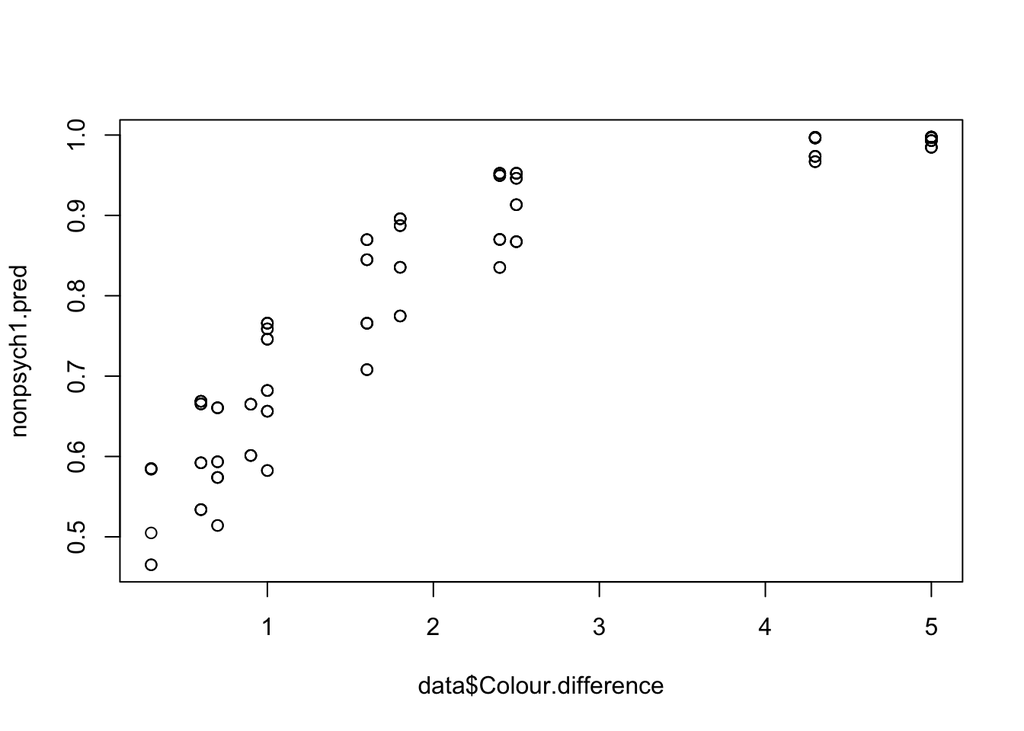

```r
xseq <- unique(data$Colour.difference) # imaginary stimulus levels to fit to. Change the high and low values, the two values after seq(,  to fit to your datas stimulus levels
newdata <- expand.grid(Colour.difference = xseq,
                       background = unique(data$background),
                       target = unique(data$target),
                       sex = unique(data$sex),
                       chick = unique(data$chick),
                       batch = unique(data$batch))
nonpsych1.pred <- predict(nonpsych2,
                          newdata = data.frame(Colour.difference = data$Colour.difference,
                                               background = data$background,
                                               target = data$target, sex = data$sex),
                          type="response",
                          re.form = NA)# ##Setting up the real data from the function
nonpsych2.pred <- predict(nonpsych2, newdata = newdata, type="response")#,se.fit=TRUE) ## Setting up the imaginary data from the function
plot(data$Colour.difference, nonpsych1.pred)
```

## Setting up the plot

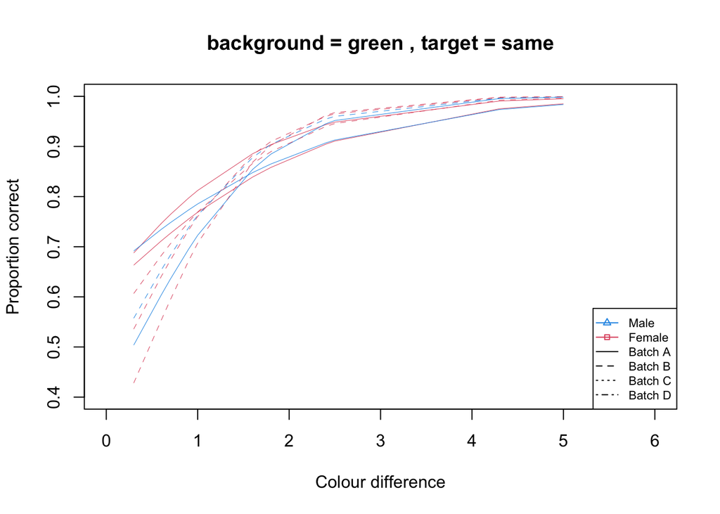

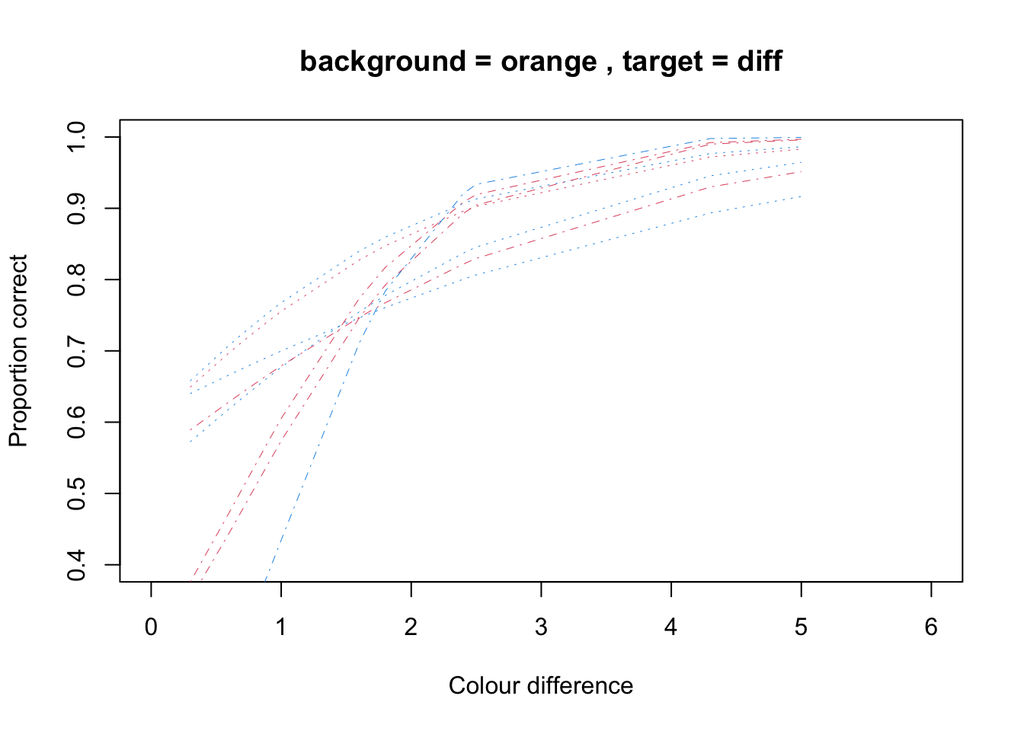

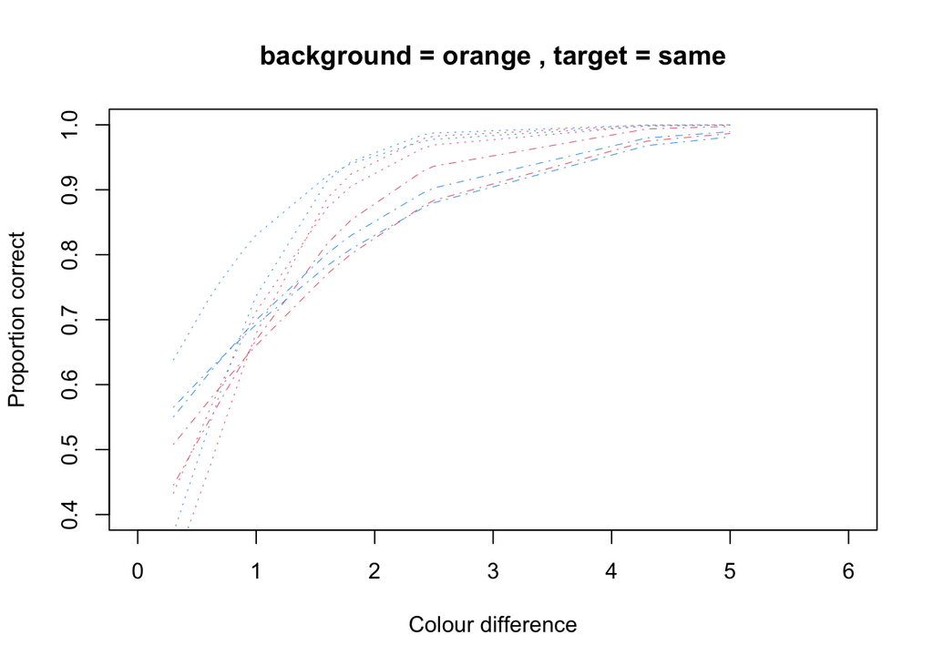

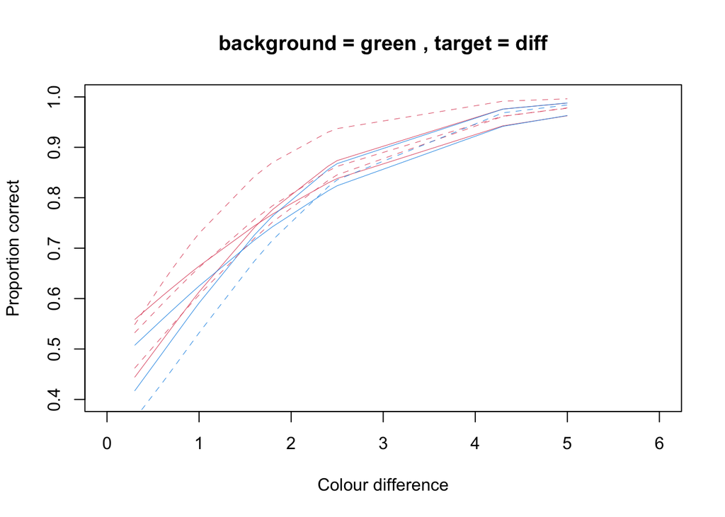

```r
bktg <- data.frame(bk = levels(data$background)[c(1,2,2,1)],
                    tg = rev(levels(newdata$target))[c(1,2,1,2)])
for(i in 1:dim(bktg)[1]){
    bk <- bktg$bk[i]
    tg <- bktg$tg[i]
  plot(NULL,
       xlab="Colour difference",
       ylab="Proportion correct",
       xlim=c(0, 6),
       ylim=c(0.4, 1),
       main = paste('background =',bk, ', target =',tg)
       )
    if(bk == 'green' & tg == 'same'){
            legend('bottomright',
                   legend = c('Male', 'Female', paste('Batch',c('A','B','C','D'))),
                   col = c(2*(2:1), rep(1, 4)),
                   lty = c(1,1,1:4),
                   pch = c(24,22,rep(NA,4)),
                   cex = 0.7)
            }
    for(ck in levels(newdata$chick)){
        if(sum(data$background == bk & data$chick == ck & data$target == tg)){
        sx <- unique(subset(data, chick == ck)$sex)
        bc <- unique(subset(data, chick == ck)$batch)
        xx <- subset(newdata,
                     background == bk & chick == ck &
                   target == tg & sex == sx & batch == bc
                     )
        yy <- nonpsych2.pred[
              newdata$background == bk & newdata$chick == ck &
                newdata$target == tg & newdata$sex == sx & newdata$batch == bc
              ]
        ORDER <- order(xx$Colour.difference)
    lines(xx$Colour.difference[ORDER],
          yy[ORDER],
          col = 2*which(unique(subset(data, chick == ck)$sex) == levels(newdata$sex)),
          lty = which(unique(subset(data, chick == ck)$batch) == levels(newdata$batch)),
          lwd = 0.5
          )
    }
    }
  points(data$Colour.difference[data$background == bk & data$target == tg],
         data$pcorr[data$background == bk & data$target == tg],
         pch = c(22,24)[as.numeric(data$sex[data$background == bk & data$target == tg])],
         bg = 'white',
         col = rgb(0,0,0,0.3),
         lwd = 2)
}
```

The following chunk defines the colour series.

```r
cls<-c("purple4","slateblue3","slateblue2","red3","green3",
       "slateblue1","pink3","orange3","navajowhite4","gray50",
       "gray70","gray30","darkblue","navajowhite2","orange4",
       "steelblue","gray10","purple3","magenta4","slateblue4",
       "green2","blue2","darkred","darkgreen","orange2",
       "seagreen","salmon4","navajowhite1","navajowhite3","yellow3",
       "blue3","magenta3")
```

#shorten as.factor for use in level sorting #N.B. unique(x) may have been more efficient than levels(as.factor(x))

```r
AF <- function(x){as.factor(x)}
```

#panels to plot in vertical and horizontal direction

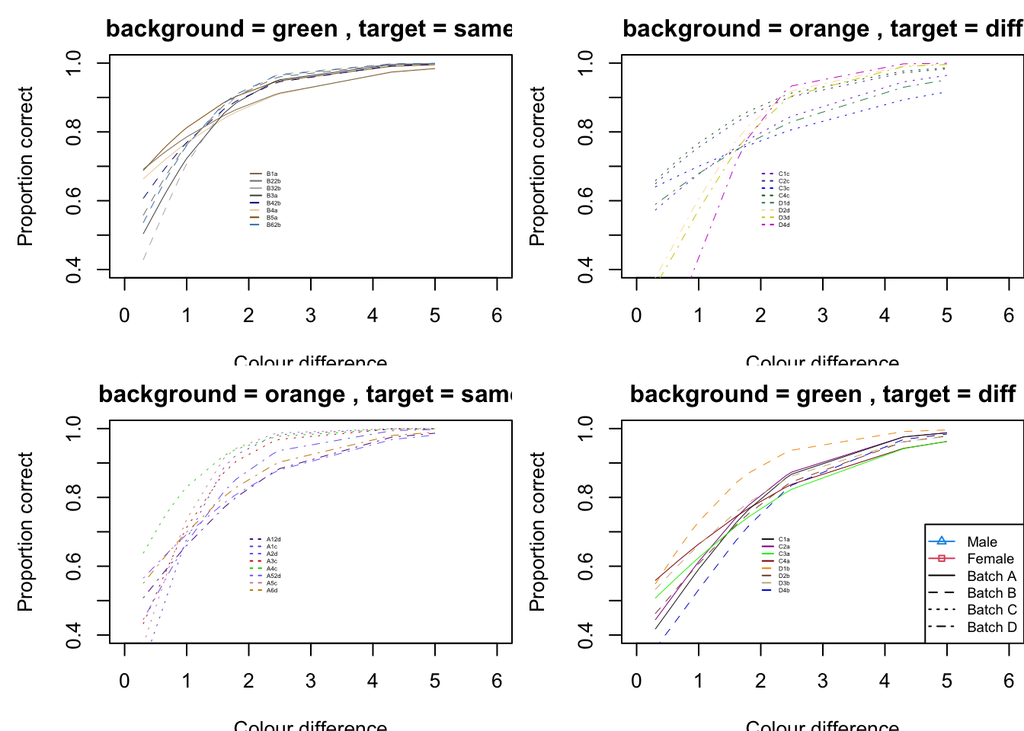

```r
hw <- c(2,2)
par(mfrow = c(hw), mai = .75*c(.8,1,.5,0))
bktg <- data.frame(bk = levels(data$background)[c(1,2,2,1)],
                            tg = rev(levels(newdata$target))[c(1,2,1,2)]
                            )
for(i in 1:dim(bktg)[1]){
    bk <- bktg$bk[i]
    tg <- bktg$tg[i]

plot(NULL,
     xlab="Colour difference",
     ylab="Proportion correct",
     xlim=c(0, 6),
     ylim=c(0.4, 1),
     main = paste('background =',bk, ', target =',tg)
     )
legend(2,0.7,#4, 0.7,
       levels(AF(data$chick[data$target == tg & data$background == bk])),
       col = cls[
                 which( levels(AF(data$chick)) %in%
                          levels(AF(data$chick[data$target == tg & data$background == bk]))
                        )
                 ],
       pch = c(22,24)[
                   as.numeric(
                     data$sex[data$Colour.difference == max(data$Colour.difference[data$chick %in%
                              levels(AF(data$chick[data$target == tg & data$background == bk]))]) &
                              data$chick %in%
                              levels(AF(data$chick[data$target == tg & data$background == bk]))]
                     )
                   ],
       cex = 1*0.3, bty = 'n', lwd = 1,
       lty = as.numeric(
               subset(data,
                      chick %in%
                        levels(AF(data$chick[data$target == tg & data$background == bk])) &
                        data$Colour.difference ==
                          max(data$Colour.difference[
                            data$chick %in% levels(AF(data$chick[data$target == tg &
                                                                   data$background == bk]))]
                            )
                      )$batch
               )
       )
  if(bk == 'green' & tg == 'diff'){
            legend('bottomright',
                   legend = c('Male', 'Female', paste('Batch',c('A','B','C','D'))),
                col = c(2*(2:1), rep(1, 4)),
                lty = c(1,1,1:4),
                pch = c(24,22,rep(NA,4)),
                cex = 0.7
            )
            }
            for(ck in levels(newdata$chick)){
                if(sum(data$background == bk & data$chick == ck & data$target == tg)){
                sx <- unique(subset(data, chick == ck)$sex)
                bc <- unique(subset(data, chick == ck)$batch)
                xx <- subset(newdata,
                             background == bk & chick == ck &
                           target == tg & sex == sx & batch == bc
                             )
                yy <- nonpsych2.pred[
                      newdata$background == bk & newdata$chick == ck &
                        newdata$target == tg & newdata$sex == sx & newdata$batch == bc
                      ]
            ORDER <- order(xx$Colour.difference)
            lines(xx$Colour.difference[ORDER],
                  yy[ORDER],
                  col = cls[which(levels(AF(data$chick)) == ck)],
                  lty = which(unique(subset(data, chick == ck)$batch) == levels(newdata$batch)),
                  lwd = 0.5 )
            points(data$Colour.difference[
                                          data$background == bk & data$chick == ck &
                                           data$target == tg & data$sex == sx &
                                            data$batch == bc
                                          ],
              data$pcorr[
                        data$background == bk & data$chick == ck &
                          data$target == tg & data$sex == sx & data$batch == bc
                        ],
              pch = c(22,24)[
                            as.numeric(
                              data$sex[
                                data$background == bk & data$target == tg & data$chick == ck
                                ]
                              )
                            ],
              bg = 'white',
              col = cls[which(levels(AF(data$chick)) == ck)],
              lwd = 2)
            }
        }
}
```

```r
ndata <- expand.grid(Colour.difference =xseq,
                     background=unique(data$background),
                     target=unique(data$target))

prd <- predict(nonpsych2, newdata = newdata, type="response", re.form = NA)
pfun <- function(x){predict(x, newdata = newdata, type = 'response')}
```

Bootstrap model confidence intervals

```r
if(Sys.info()[['sysname']] == 'Windows')
  {
  require(snow); clt <- makeCluster(parallel::detectCores(), type = 'SOCK')
  clusterExport(clt,list('nonpsych2','pfun','newdata'))
  boot <- bootMer(nonpsych2, pfun, nsim = 10^2, re.form = NA,
                  parallel = c("snow"), ncpus = parallel::detectCores(), cl = clt)
  stopCluster(clt)
  }else
  {
  boot <- bootMer(nonpsych2, pfun, nsim = 10^2, re.form = NA,
                 parallel = c("multicore"), ncpus = parallel::detectCores())
  }
```

Calculate confidence intervals from bootstrapped model

```r
stqlog   <- function(x){ sd(qlogis(x), na.rm = T)}
std.err <- apply(boot$t, 2, stqlog)#standard error for each
CI.lo <- plogis(qlogis(prd) - std.err*1.96)#lower confidence bound (parametric)
CI.hi <- plogis(qlogis(prd) + std.err*1.96)#upper confidence bound (parametric)
bootsdata <- cbind(newdata, CI.lo, CI.hi)
CI.lo. <- with(bootsdata, aggregate(CI.lo, list(Colour.difference = Colour.difference, background = background, target = target), mean))
CI.hi. <- with(bootsdata, aggregate(CI.hi, list(Colour.difference = Colour.difference, background = background, target = target), mean))
```

Also check bootstrapped parameter estimates

```r
ciii <- confint(boot, parallel = c("multicore"),ncpus = parallel::detectCores())
paramdata <- cbind(newdata, ciii)
#mean should be in logit space
lgtmean <- function(x){plogis(mean(qlogis(x)))}
CI.02.5 <- with(paramdata, aggregate(`2.5 %`, list(Colour.difference = Colour.difference, background = background, target = target), lgtmean))#mean))
CI.97.5 <- with(paramdata, aggregate(`97.5 %`, list(Colour.difference = Colour.difference, background = background, target = target), lgtmean))#mean))
```

### Find sensible averages for each condition

```r
estdata <- cbind(newdata, prd)[order(newdata$Colour.difference),]
estcurve <- with(estdata, aggregate(prd, list(Colour.difference = Colour.difference, background = background, target = target), lgtmean))

threshquant <- list(same = (0:20/100), diff = (0:40/100))
```

```r
hw <- c(2,2)
par(mfrow = c(hw), mai = .75*c(.8,1,.5,0))
bktg <- data.frame(bk = levels(data$background)[c(1,2,2,1)],
                    tg = rev(levels(newdata$target))[c(1,2,1,2)])
for(i in 1:dim(bktg)[1]){
    bk <- bktg$bk[i]
    tg <- bktg$tg[i]
    plot(NULL, xlab="Colour difference", ylab="Proportion correct", xlim=c(0, 6), ylim=c(0.4, 1), main = paste('background =',bk, ', target =', tg))

                xx <- subset(estcurve, background == bk & target == tg)$Colour.difference
                yy <- subset(estcurve, background == bk & target == tg)$x
                threshness <-abs(yy - 0.65)
                threshx <- mean(xx[threshness %in% quantile(threshness, unlist(threshquant[2 - i %% 2])) ])
                print(threshx)
                        polygon(c(subset(CI.02.5, background == bk & ndata$target == tg)$Colour.difference, rev(subset(CI.97.5, background == bk & ndata$target == tg)$Colour.difference)), c(subset(CI.02.5, background == bk & ndata$target == tg)$x,rev(subset(CI.97.5, background == bk & ndata$target == tg)$x)) , col = 'gray', border = rgb(0,0,0,0))
            # lines(xx[ORDER], yy[ORDER], col = 'black', lty = 1, lwd = 5)
                lines(xx, yy, col = 'black', lty = 1, lwd = 1)

points(data$Colour.difference[data$background == bk & data$target == tg], data$pcorr[data$background == bk & data$target == tg], pch = c(22,24)[as.numeric(data$sex[data$background == bk & data$target == tg])], bg = 'white', col = rgb(0,0,0,0.3), lwd = 2)
lines(rep(threshx, 2), c(0.36, 0.65), lty = 2)
lines(c(-0.25,threshx), rep(0.65,2), lty = 2)
}
```

```
## [1] 0.5333333
```

```
## [1] 0.96
```

```
## [1] 0.8666667
```

```
## [1] 0.96
```

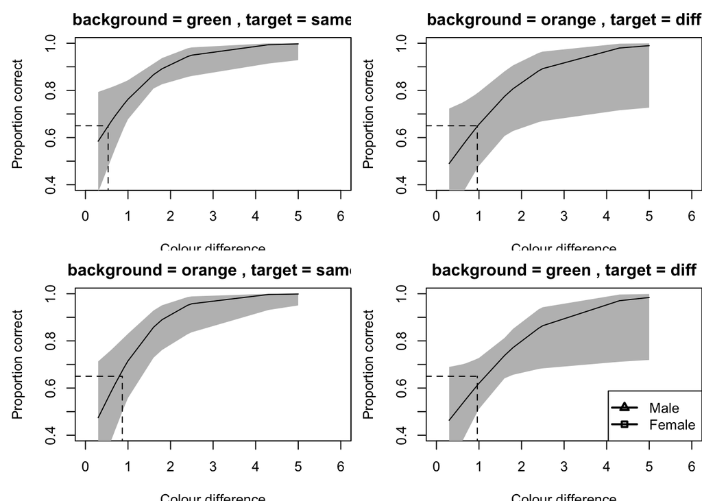

```r
legend('bottomright', legend = c('Male', 'Female'),
        col = c(1,1), pch = c(24,22), lwd = c(2,2))
```

```r
std.err <- apply(boot$t, 2, stqlog)#standard error for each
CI.lo.se <- plogis(qlogis(prd) - std.err)#lower se bound (parametric)
CI.hi.se <- plogis(qlogis(prd) + std.err)#upper se bound (parametric)
bootsdata.se <- cbind(newdata, CI.lo.se, CI.hi.se)
CI.lo.se. <- with(bootsdata.se, aggregate(CI.lo.se, list(Colour.difference = Colour.difference, background = background, target = target), lgtmean))
CI.hi.se. <- with(bootsdata.se, aggregate(CI.hi.se, list(Colour.difference = Colour.difference, background = background, target = target), lgtmean))
```

Make a function to evaluate the threshold.

```r
thresholder <- function(xx,yy,lev){
                diff. <- sort(yy-lev)
                close. <- min(abs(diff.))
                if(sign(diff.[abs(diff.) == close.]) == 0){
                    return( xx[which(abs(diff.) == close.) + c(0)]  )
                }else{
                    if(sign(diff.[abs(diff.) == close.]) == 1){
                        if(which(abs(diff.) == close.) == 1){
                        return( xx[1])
                        }else{
                    ab. <-  xx[which(abs(diff.) == close.) + c(-1,0)]
                        }
                    }else{
                    ab. <-  xx[which(abs(diff.) == close.) + c(0,1)]
                    }
                    ty. <- yy[xx %in% ab.]
                xxt. <- seq(min(ab.), max(ab.), length.out = 10^3)
                yyt. <- (xxt.-min(ab.))*diff(ty.)/diff(ab.) + min(ty.)
                return( mean(xxt.[round(yyt.,2) == lev])    )
                }
}
```

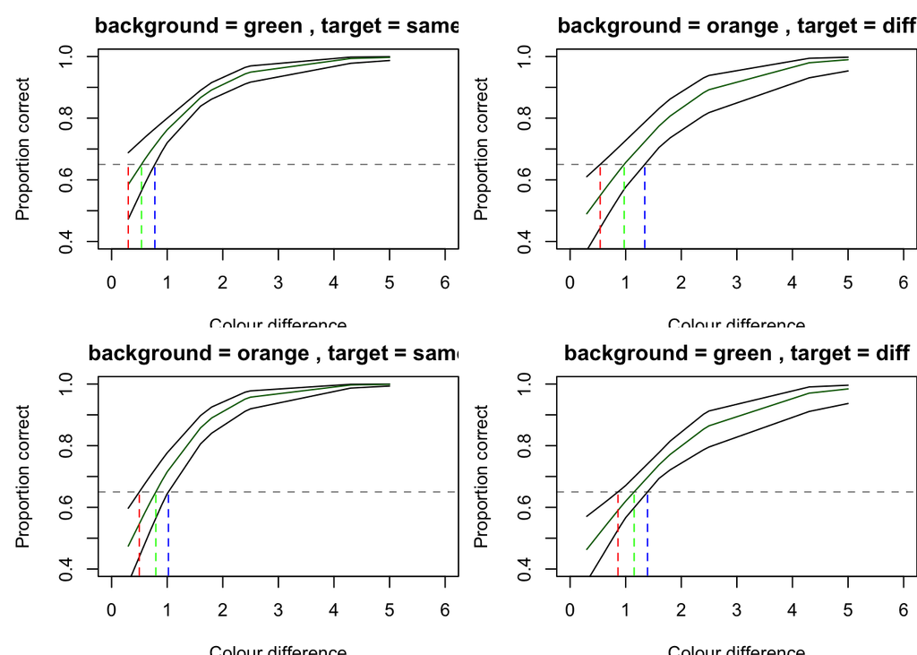

```r
par(mfrow = c(hw), mai = .75*c(.8,1,.5,0))

for(i in 1:dim(bktg)[1]){
    bk <- bktg$bk[i]
    tg <- bktg$tg[i]
    plot(NULL, xlab="Colour difference", ylab="Proportion correct",
         xlim=c(0, 6),  ylim=c(0.4, 1),
         main = paste('background =',bk, ', target =', tg))
    abline(h = 0.65, lty = 2, lwd = 0.5)
    x1 <- subset(estcurve, background == bk & target == tg)$Colour.difference
    y1 <- subset(estcurve, background == bk & target == tg)$x
    xx <- sort(unique(subset(CI.lo.se., background == bk & target==tg)$Colour.difference ))
    yy.lo <- sort(unique(   subset(CI.lo.se., background == bk & target == tg)$x    ))
    yy.hi <- sort(unique(   subset(CI.hi.se., background == bk & target == tg)$x    ))
    lines(xx, yy.lo)
    lines(xx, yy.hi)
    lines(x1, y1, col = 'darkgreen')
    assign(paste0('t.', tg, bk), thresholder(x1,y1,0.65))
    lines(rep(get(paste0('t.', tg, bk)),2), c(0.38, 0.65), lty = 2, col = 'green')
    assign(paste0('t.se.lo.', tg, bk), thresholder(xx,yy.hi,0.65))
    lines(rep(get(paste0('t.se.lo.', tg, bk)),2), c(0.38, 0.65), lty = 2,col ='red')
                assign(paste0('t.se.hi.', tg, bk), thresholder(xx,yy.lo,0.65))
    lines(rep(get(paste0('t.se.hi.', tg, bk)),2), c(0.38, 0.65), lty = 2,col ='blue')
    }
```

## The “binomial” 65% threshold

JND for chickens discriminating orange colours on an orange background

```r
diff(round( c(
            t.se.lo.sameorange,
            t.se.hi.sameorange  ),  2)
            )
```

```
## [1] 0.52
```

JND for chickens discriminating orange colours on a green background

```r
diff(round( c(
            t.se.lo.diffgreen,
            t.se.hi.diffgreen   ),  2)
      )
```

```
## [1] 0.53
```

JND for chickens discriminating green colours on an orange background.

```r
diff(round( c(
            t.se.lo.difforange,
            t.se.hi.difforange  ),  2)
)
```

```
## [1] 0.8
```

JND for chickens discriminating green colours on an green background.

```r
diff(round( c(
            t.se.lo.samegreen,
            t.se.hi.samegreen   ),  2)
)
```

```
## [1] 0.48
```